# desiguales produccion

miércoles 12 julio 2023 16:19:47

# 1 Cargar paquetes

```r
options(scipen=999)
pacman::p_load(dplyr, haven, stargazer, sjmisc, sjPlot, tidyverse, ggplot2, survey, srvyr, ggpubr)
```

# 2 cargar base de datos desiguales 2016 (del PNUD)

```r
load("input/proc/desiguales_rec.RData")
```

## 2.1 Ponderadores

```r
data_rec$sexo <- factor(data_rec$sexo, labels = c("Hombre", "Mujer"))
data_rec$sexo <- factor(data_rec$sexo, levels = c("Mujer", "Hombre"))
desiguales_pond <- data_rec %>% as_survey_design(ids = 1,
                                                 weights = WEIGHT)
```

# 3 Diferencias de media

- media de percepción cuánto ganan en cada oficio diferenciado por sexo, según sexo

```r
salario_real = desiguales_pond %>% group_by(sexo) %>%
  summarise(n = n(),
            cajero_hombre = survey_mean(p12_sal_real_cajero_h, na.rm = T),
            cajero_mujer = survey_mean(p12_sal_real_cajero_m, na.rm = T),
            gerente_hombre = survey_mean(p12_sal_real_gerente_h, na.rm = T),
            gerente_mujer = survey_mean(p12_sal_real_gerente_m, na.rm = T),
            doctor_hombre = survey_mean(p12_sal_real_doctor_h, na.rm = T),
            doctor_mujer = survey_mean(p12_sal_real_doctor_m, na.rm = T),
            diputado_hombre = survey_mean(p12_sal_real_diput_h, na.rm = T),
            diputado_mujer = survey_mean(p12_sal_real_diput_m, na.rm = T)
            )
```

```r
salario_real_long <- salario_real %>%
  pivot_longer(cols = c("cajero_hombre",
                        "cajero_mujer",
                        "doctor_hombre",
                        "doctor_mujer",
                        "gerente_hombre",
                        "gerente_mujer",
                        "diputado_hombre",
                        "diputado_mujer"),
               names_to = "oficio",
               values_to = "mean")

salario_real_long$oficio <- factor(salario_real_long$oficio, levels = c("cajero_hombre", "cajero_mujer", "doctor_hombre", "doctor_mujer", "diputado_hombre", "diputado_mujer", "gerente_hombre", "gerente_mujer"))
```

## 3.1 Gráfico diferencias de media

### 3.1.1 salario percibido hombres

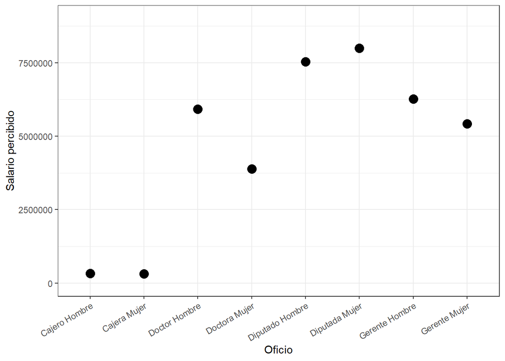

```r
p12_sal_perc_h <- salario_real_long %>% filter(sexo=="Hombre") %>%
  ggplot(aes(x = oficio, y = mean)) +
  geom_point(size=4) +
  xlab("Oficio") + ylab("Salario percibido")  +
  ylim(0, 9000000) +
  theme_bw() +
  theme(axis.text.x = element_text(angle = 30, hjust = 1)) +
  scale_x_discrete(label = c("Cajero Hombre", "Cajera Mujer", "Doctor Hombre", "Doctora Mujer", "Diputado Hombre", "Diputada Mujer", "Gerente Hombre", "Gerente Mujer"))

p12_sal_perc_h
```

### 3.1.2 salario percibido mujeres

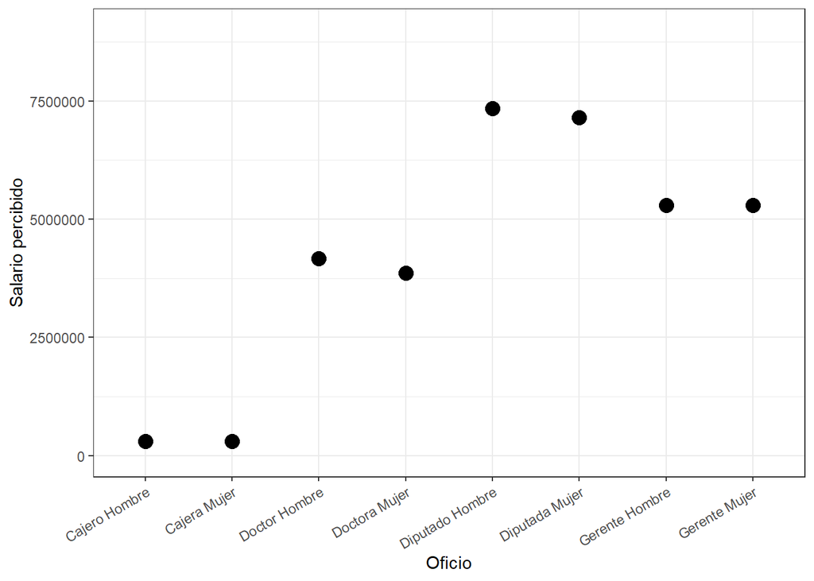

```r
p12_sal_perc_m <- salario_real_long %>% filter(sexo=="Mujer") %>%
  ggplot(aes(x = oficio, y = mean)) +
  geom_point(size=4) +
  xlab("Oficio") + ylab("Salario percibido")  +
  ylim(0, 9000000) +
  theme_bw() +
  theme(axis.text.x = element_text(angle = 30, hjust = 1)) +
  scale_x_discrete(label = c("Cajero Hombre", "Cajera Mujer", "Doctor Hombre", "Doctora Mujer", "Diputado Hombre", "Diputada Mujer", "Gerente Hombre", "Gerente Mujer"))

p12_sal_perc_m
```

- ideal

Media de percepción cuánto deberían ganar en cada oficio diferenciado por sexo, según sexo

```r
salario_ideal = desiguales_pond %>% group_by(sexo) %>%
  summarise(n = n(),
            cajero_hombre = survey_mean(p12_sal_ideal_cajero_h, na.rm = T),
            cajero_mujer = survey_mean(p12_sal_ideal_cajero_m, na.rm = T),
            gerente_hombre = survey_mean(p12_sal_ideal_gerente_h, na.rm = T),
            gerente_mujer = survey_mean(p12_sal_ideal_gerente_m, na.rm = T),
            doctor_hombre = survey_mean(p12_sal_ideal_doctor_h, na.rm = T),
            doctor_mujer = survey_mean(p12_sal_ideal_doctor_m, na.rm = T),
            diputado_hombre = survey_mean(p12_sal_ideal_diput_h, na.rm = T),
            diputado_mujer = survey_mean(p12_sal_ideal_diput_m, na.rm = T)
            )
```

```r
salario_ideal_long <- salario_ideal %>%
  pivot_longer(cols = c("cajero_hombre",
                        "cajero_mujer",
                        "gerente_hombre",
                        "gerente_mujer",
                        "doctor_hombre",
                        "doctor_mujer",
                        "diputado_hombre",
                        "diputado_mujer"),
               names_to = "oficio",
               values_to = "mean")

salario_ideal_long$oficio <- factor(salario_ideal_long$oficio, levels = c("cajero_hombre", "cajero_mujer", "doctor_hombre", "doctor_mujer", "diputado_hombre", "diputado_mujer", "gerente_hombre", "gerente_mujer"))
```

## 3.2 Gráfico diferencias de media

### 3.2.1 salario ideal hombres

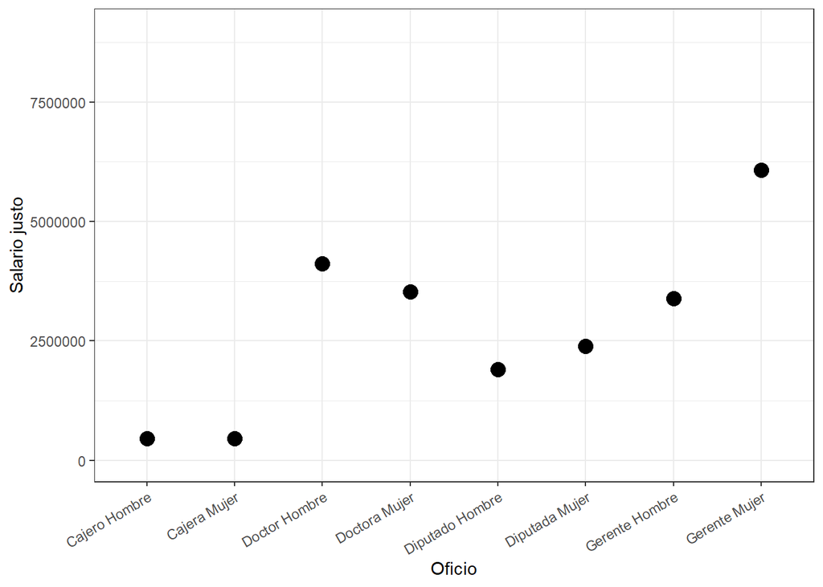

```r
p12_sal_ideal_h <- salario_ideal_long %>% filter(sexo=="Hombre") %>%
  ggplot(aes(x = oficio, y = mean)) +
  geom_point(size=4) +
  xlab("Oficio") + ylab("Salario justo")  +
  ylim(0, 9000000) +
  theme_bw() +
  theme(axis.text.x = element_text(angle = 30, hjust = 1)) +
  scale_x_discrete(label = c("Cajero Hombre", "Cajera Mujer", "Doctor Hombre", "Doctora Mujer", "Diputado Hombre", "Diputada Mujer", "Gerente Hombre", "Gerente Mujer"))

p12_sal_ideal_h
```

### 3.2.2 salario ideal mujeres

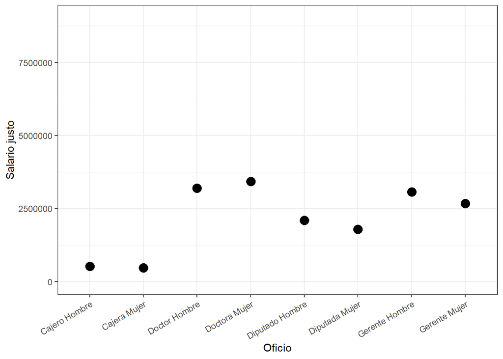

```r
p12_sal_ideal_m <- salario_ideal_long %>% filter(sexo=="Mujer") %>%
  ggplot(aes(x = oficio, y = mean)) +
  geom_point(size=4) +
  xlab("Oficio") + ylab("Salario justo")  +
  ylim(0, 9000000) +
  theme_bw() +
  theme(axis.text.x = element_text(angle = 30, hjust = 1)) +
  scale_x_discrete(label = c("Cajero Hombre", "Cajera Mujer", "Doctor Hombre", "Doctora Mujer", "Diputado Hombre", "Diputada Mujer", "Gerente Hombre", "Gerente Mujer"))

p12_sal_ideal_m
```

```r
p12_sal_m <- ggarrange(p12_sal_perc_m, p12_sal_ideal_m, ncol=2)
p12_sal_h <- ggarrange(p12_sal_perc_h, p12_sal_ideal_h, ncol=2)

ggsave(p12_sal_m, file = "output/graphs/des_media_salarios_mujeres.png", width = 8,height = 10)
ggsave(p12_sal_h, file = "output/graphs/des_media_salarios_hombres.png", width = 8,height = 10)
```

### 3.2.3 comparacion ambos tipos de salarios

- mujeres

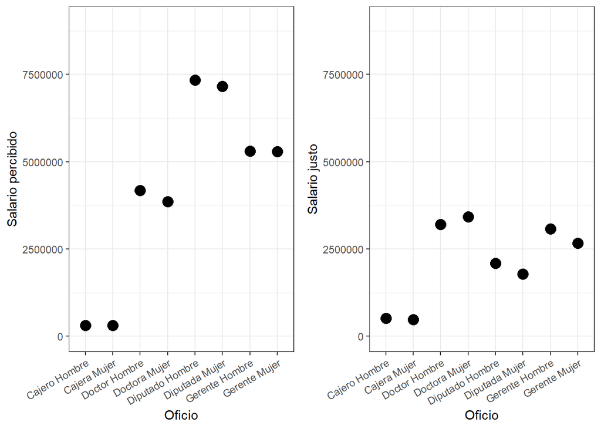

```r
p12_sal_m
```

- hombres

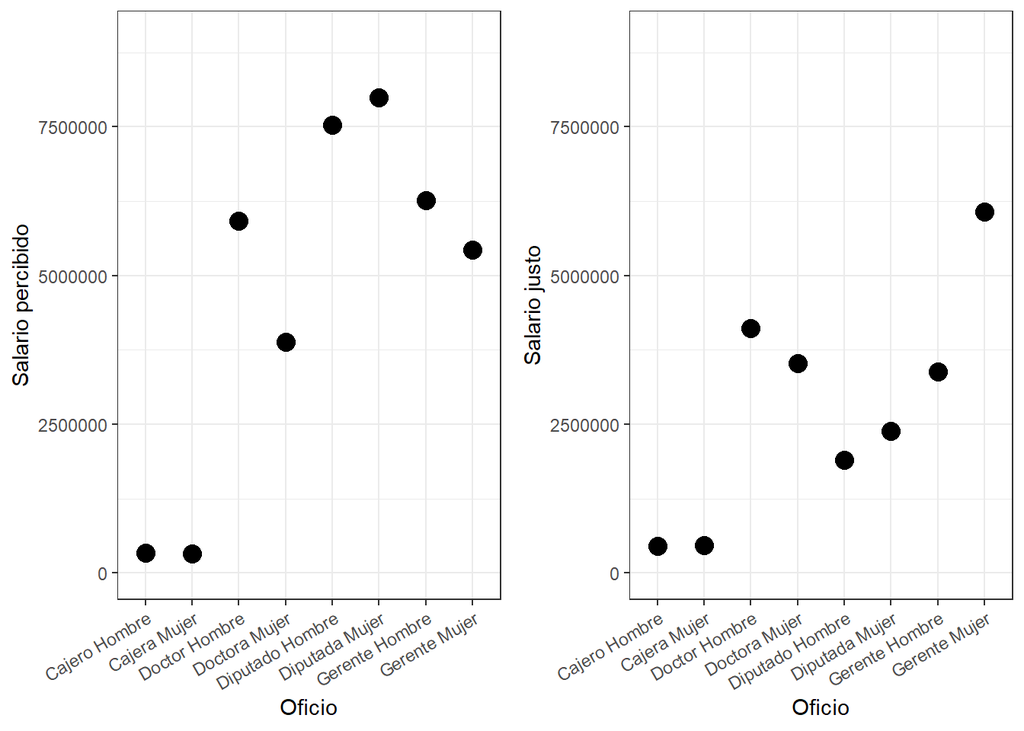

```r
p12_sal_h
```

### 3.2.4 Comparacion mismo tipo de salario ambos sexos

izquierda mujer, derecha hombre

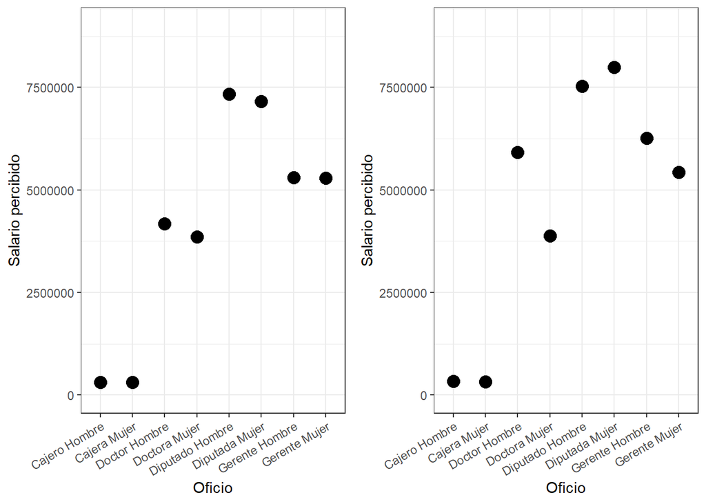

```r
p12_ideal <-ggarrange(p12_sal_perc_m, p12_sal_perc_h, ncol=2)
p12_ideal
```

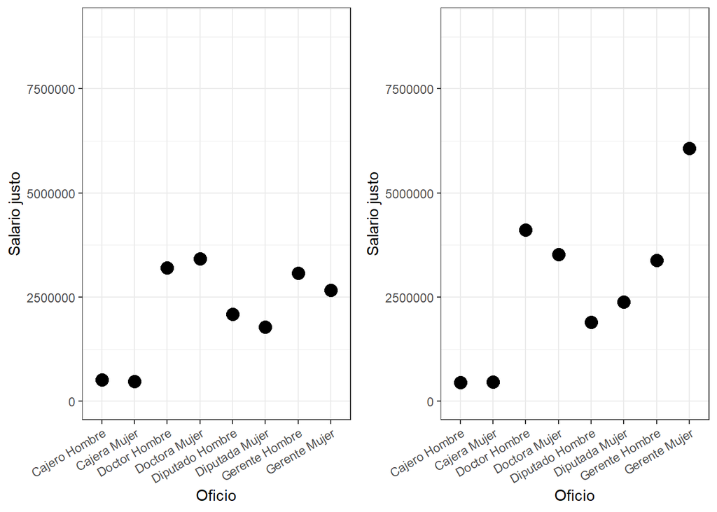

```r
p12_real <- ggarrange(p12_sal_ideal_m, p12_sal_ideal_h, ncol=2)
p12_real
```

# 4 salario real (mediana de percepción cuánto ganan en cada oficio diferenciado por sexo, según sexo)

```r
salario_real = desiguales_pond %>% group_by(sexo) %>%
  summarise(n = n(),
            cajero_hombre = survey_median(p12_sal_real_cajero_h, na.rm = T),
            cajero_mujer = survey_median(p12_sal_real_cajero_m, na.rm = T),
            gerente_hombre = survey_median(p12_sal_real_gerente_h, na.rm = T),
            gerente_mujer = survey_median(p12_sal_real_gerente_m, na.rm = T),
            doctor_hombre = survey_median(p12_sal_real_doctor_h, na.rm = T),
            doctor_mujer = survey_median(p12_sal_real_doctor_m, na.rm = T),
            diputado_hombre = survey_median(p12_sal_real_diput_h, na.rm = T),
            diputado_mujer = survey_median(p12_sal_real_diput_m, na.rm = T)
            )
```

```r
salario_real_long <- salario_real %>%
  pivot_longer(cols = c("cajero_hombre",
                        "cajero_mujer",
                        "gerente_hombre",
                        "gerente_mujer",
                        "doctor_hombre",
                        "doctor_mujer",
                        "diputado_hombre",
                        "diputado_mujer"),
               names_to = "oficio",
               values_to = "mean")

salario_real_long$oficio <- factor(salario_real_long$oficio, levels = c("cajero_hombre", "cajero_mujer", "doctor_hombre", "doctor_mujer", "diputado_hombre", "diputado_mujer", "gerente_hombre", "gerente_mujer"))
```

## 4.1 Gráfico diferencias de mediana

### 4.1.1 Salario percibido hombres

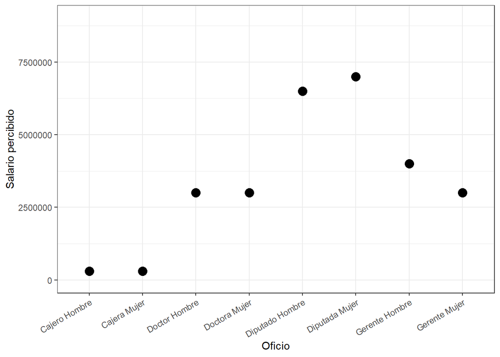

```r
p12_sal_real_h <- salario_real_long %>% filter(sexo=="Hombre") %>%
  ggplot(aes(x = oficio, y = mean)) +
  geom_point(size=4) +
  xlab("Oficio") + ylab("Salario percibido")  +
  theme_bw() +
  ylim(0, 9000000) +
  theme(axis.text.x = element_text(angle = 30, hjust = 1)) +
  scale_x_discrete(label = c("Cajero Hombre", "Cajera Mujer", "Doctor Hombre", "Doctora Mujer", "Diputado Hombre", "Diputada Mujer", "Gerente Hombre", "Gerente Mujer"))

p12_sal_real_h
```

### 4.1.2 Salario percibido mujeres

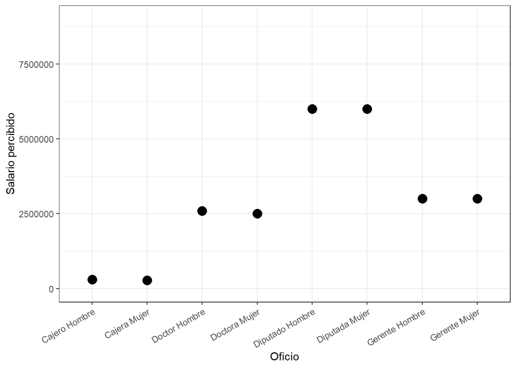

```r
p12_sal_real_m <- salario_real_long %>% filter(sexo=="Mujer") %>%
  ggplot(aes(x = oficio, y = mean)) +
  geom_point(size=4) +
  xlab("Oficio") + ylab("Salario percibido")  +
  theme_bw() +
  ylim(0, 9000000) +
  theme(axis.text.x = element_text(angle = 30, hjust = 1)) +
  scale_x_discrete(label = c("Cajero Hombre", "Cajera Mujer", "Doctor Hombre", "Doctora Mujer", "Diputado Hombre", "Diputada Mujer", "Gerente Hombre", "Gerente Mujer"))

p12_sal_real_m
```

# 5 salario ideal (Mediana de percepción cuánto deberían ganar en cada oficio diferenciado por sexo, según sexo)

```r
salario_ideal = desiguales_pond %>% group_by(sexo) %>%
  summarise(n = n(),
            cajero_hombre = survey_median(p12_sal_ideal_cajero_h, na.rm = T),
            cajero_mujer = survey_median(p12_sal_ideal_cajero_m, na.rm = T),
            gerente_hombre = survey_median(p12_sal_ideal_gerente_h, na.rm = T),
            gerente_mujer = survey_median(p12_sal_ideal_gerente_m, na.rm = T),
            doctor_hombre = survey_median(p12_sal_ideal_doctor_h, na.rm = T),
            doctor_mujer = survey_median(p12_sal_ideal_doctor_m, na.rm = T),
            diputado_hombre = survey_median(p12_sal_ideal_diput_h, na.rm = T),
            diputado_mujer = survey_median(p12_sal_ideal_diput_m, na.rm = T)
            )
```

```r
salario_ideal_long <- salario_ideal %>%
  pivot_longer(cols = c("cajero_hombre",
                        "cajero_mujer",
                        "gerente_hombre",
                        "gerente_mujer",
                        "doctor_hombre",
                        "doctor_mujer",
                        "diputado_hombre",
                        "diputado_mujer"),
               names_to = "oficio",
               values_to = "mean")


salario_ideal_long$oficio <- factor(salario_ideal_long$oficio, levels = c("cajero_hombre", "cajero_mujer", "doctor_hombre", "doctor_mujer", "diputado_hombre", "diputado_mujer", "gerente_hombre", "gerente_mujer"))
```

## 5.1 Gráfico diferencias de mediana

### 5.1.1 Salario ideal hombres

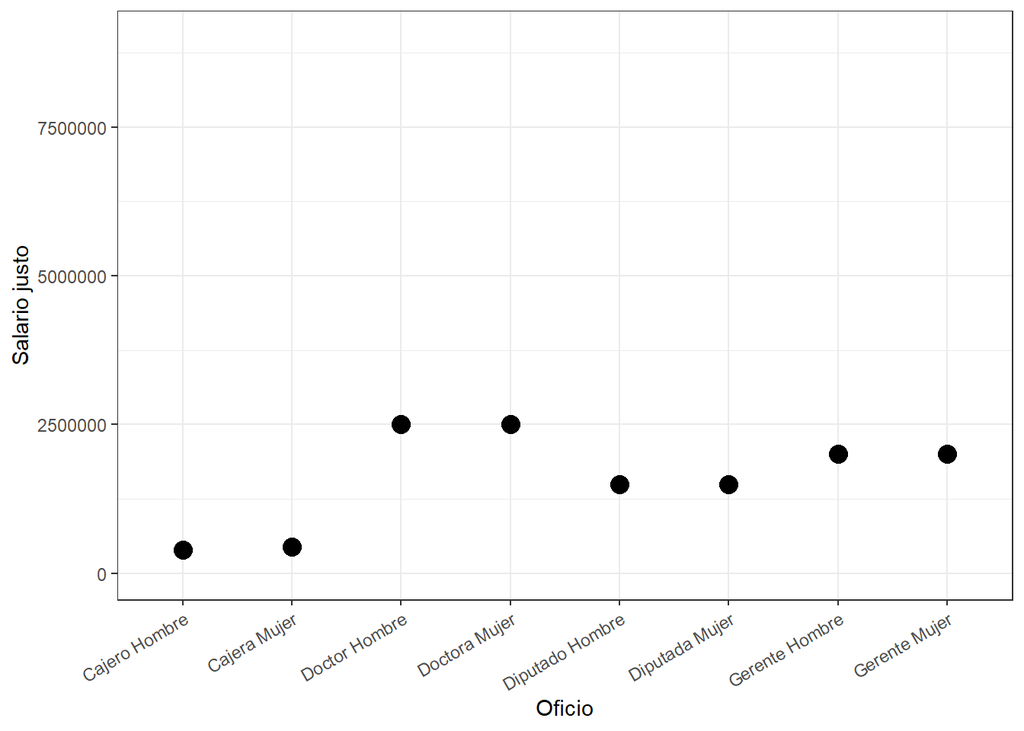

```r
p12_sal_ideal_h <- salario_ideal_long %>% filter(sexo=="Hombre") %>%
  ggplot(aes(x = oficio, y = mean)) +
  geom_point(size=4) +
  xlab("Oficio") + ylab("Salario justo")  +
  theme_bw() +
  ylim(0, 9000000) +
  theme(axis.text.x = element_text(angle = 30, hjust = 1)) +
  scale_x_discrete(label = c("Cajero Hombre", "Cajera Mujer", "Doctor Hombre", "Doctora Mujer", "Diputado Hombre", "Diputada Mujer", "Gerente Hombre", "Gerente Mujer"))

p12_sal_ideal_h
```

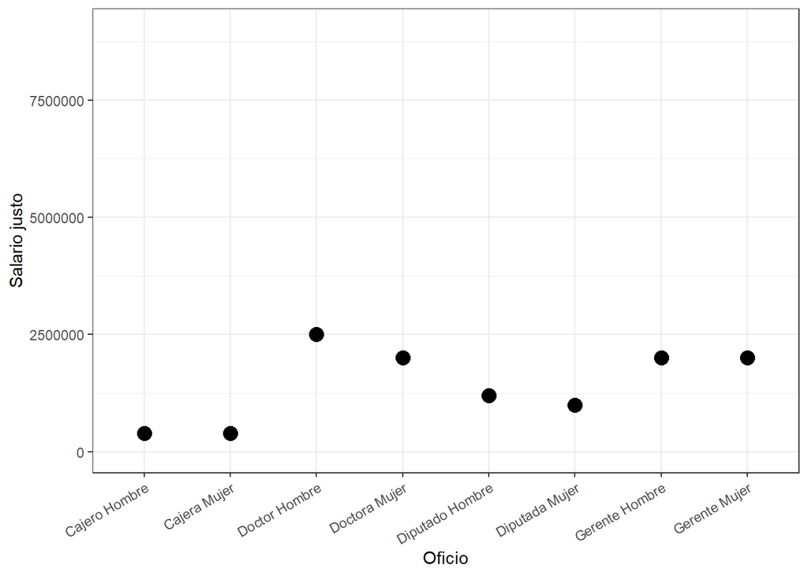

```r
p12_sal_ideal_m <- salario_ideal_long %>% filter(sexo=="Mujer") %>%
  ggplot(aes(x = oficio, y = mean)) +
  geom_point(size=4) +
  xlab("Oficio") + ylab("Salario justo")  +
  theme_bw() +
  ylim(0, 9000000) +
  theme(axis.text.x = element_text(angle = 30, hjust = 1)) +
  scale_x_discrete(label = c("Cajero Hombre", "Cajera Mujer", "Doctor Hombre", "Doctora Mujer", "Diputado Hombre", "Diputada Mujer", "Gerente Hombre", "Gerente Mujer"))

p12_sal_ideal_m
```

```r
median_salarios_hombres <- ggarrange(p12_sal_real_h, p12_sal_ideal_h, ncol = 2)
median_salarios_mujeres <- ggarrange(p12_sal_real_m, p12_sal_ideal_m, ncol = 2)

ggsave(median_salarios_hombres, file = "output/graphs/des_median_salarios_hombres.png", width = 8,height = 10)
ggsave(median_salarios_mujeres, file = "output/graphs/des_median_salarios_mujeres.png", width = 8,height = 10)
```

### 5.1.3 Comparacion ambos tipos de salarios

- mujeres

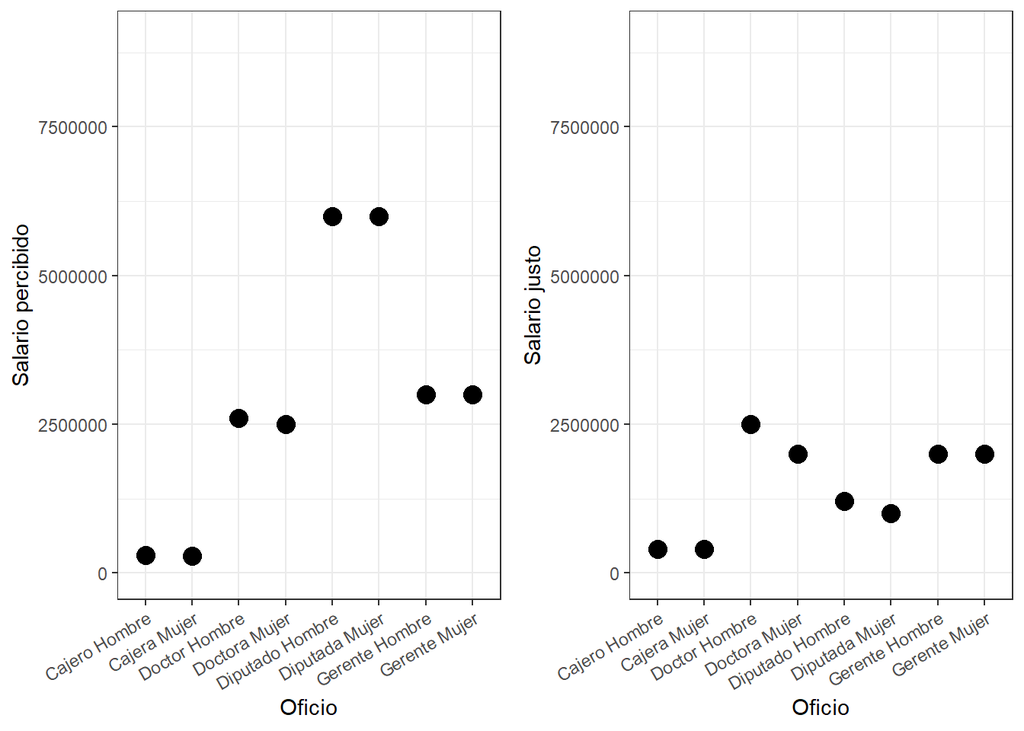

```r
median_salarios_mujeres
```

- hombres

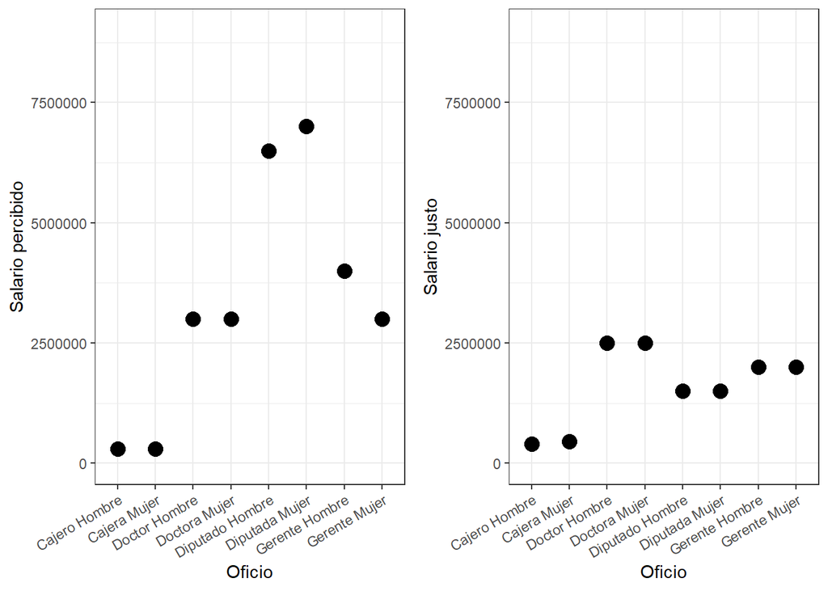

```r
median_salarios_hombres
```

### 5.1.4 Comparación mismo tipo de salario ambos sexos

izquierda mujer, derecha hombre

- ideal

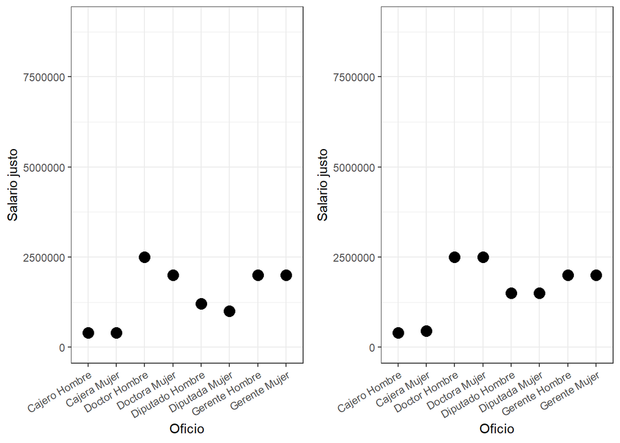

```r
median_salarios_ideal <- ggarrange(p12_sal_ideal_m, p12_sal_ideal_h, ncol = 2)
median_salarios_ideal
```

- real

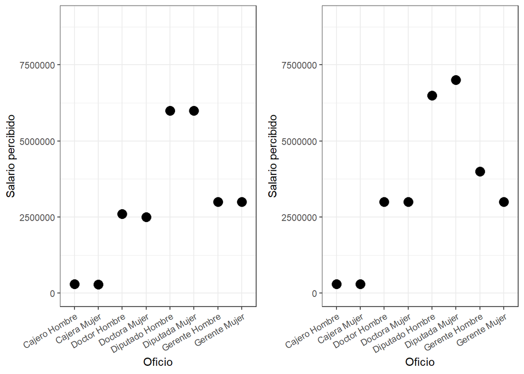

```r
median_salarios_real <- ggarrange(p12_sal_real_m, p12_sal_real_h, ncol = 2)
median_salarios_real
```

##### 5.1.4.0.1 los de acá abajo los descartamos (demasiada información)

```r
salario_ideal_long <- salario_ideal_long %>% select(sexo, oficio, salario_ideal = mean)
salario_real_long <- salario_real_long %>% select(salario_real = mean)

base <- cbind(salario_ideal_long, salario_real_long)

base_long <- base %>%
  pivot_longer(cols = c("salario_ideal",
                        "salario_real"),
               names_to = "tipo",
               values_to = "mean")
base_long$tipo <- factor(base_long$tipo, levels = c("salario_real", "salario_ideal"))
base_long$tipo <- factor(base_long$tipo, labels = c("Salario percibido", "Salario justo"))
```

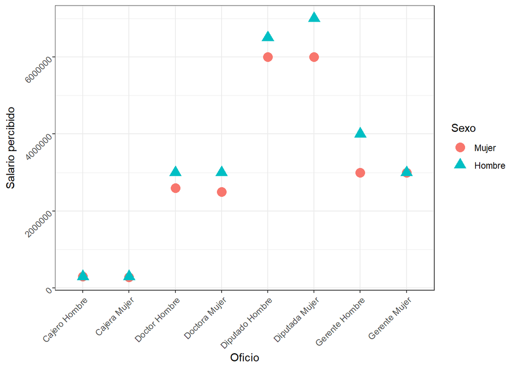

```r
plot_percibido <- base_long %>% filter(tipo=="Salario percibido") %>%
  ggplot(aes(x = oficio, y = mean, color=sexo)) +
  geom_point(size=4, aes(shape=sexo)) +
  labs(color = "Sexo", shape="Sexo") +
  xlab("Oficio") + ylab("Salario percibido")  +
  theme_bw() +
  theme(axis.text = element_text(angle = 45, hjust = 1),
        strip.text.x = element_text(size = 14)) +
  scale_x_discrete(label = c("Cajero Hombre", "Cajera Mujer", "Doctor Hombre", "Doctora Mujer", "Diputado Hombre", "Diputada Mujer", "Gerente Hombre", "Gerente Mujer"))

plot_percibido
```

```r
ggsave(plot_percibido, file = "output/graphs/des_median_salarios_real.png", width = 12,height = 7)
```

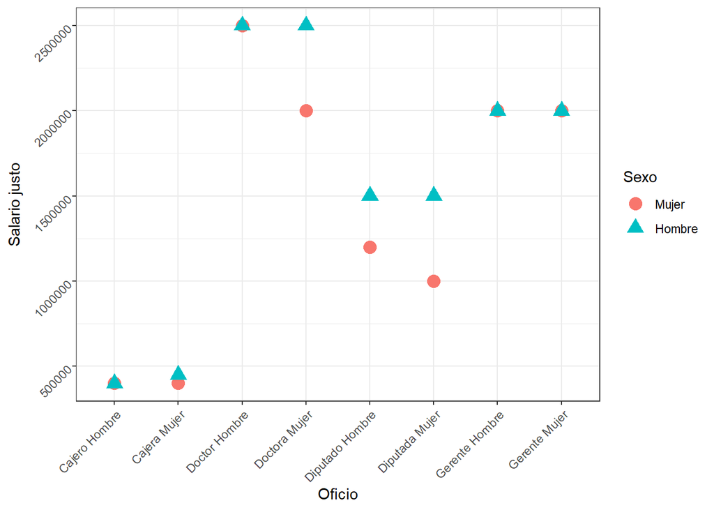

```r
plot_justo <- base_long %>% filter(tipo=="Salario justo") %>%
  ggplot(aes(x = oficio, y = mean, color=sexo)) +
  geom_point(size=4, aes(shape=sexo)) +
  labs(color = "Sexo", shape="Sexo") +
  xlab("Oficio") + ylab("Salario justo")  +
  theme_bw() +
  theme(axis.text = element_text(angle = 45, hjust = 1),
        strip.text.x = element_text(size = 14)) +
  scale_x_discrete(label = c("Cajero Hombre", "Cajera Mujer", "Doctor Hombre", "Doctora Mujer", "Diputado Hombre", "Diputada Mujer", "Gerente Hombre", "Gerente Mujer"))

plot_justo
```

```r
ggsave(plot_justo, file = "output/graphs/des_median_salarios_ideal.png", width = 12,height = 7)
```

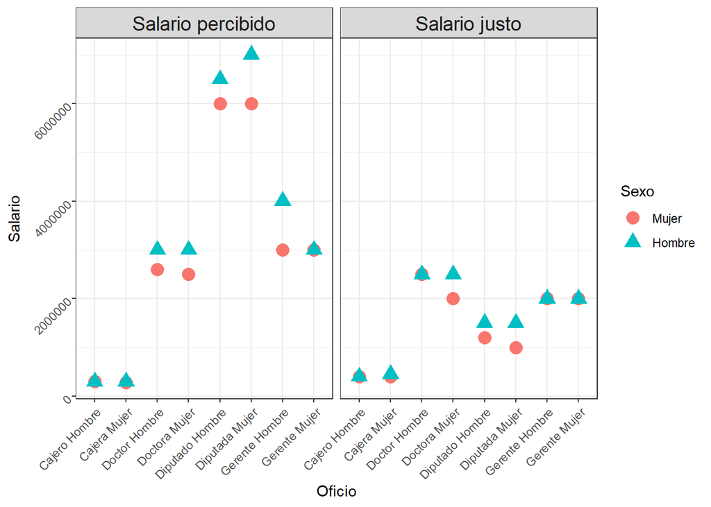

```r
plot_tipo <- ggplot(base_long, aes(x = oficio, y = mean, color=sexo)) +
  geom_point(size=4, aes(shape=sexo)) +
  labs(color = "Sexo", shape="Sexo") +
  xlab("Oficio") + ylab("Salario")  +
  theme_bw() +
  theme(axis.text = element_text(angle = 45, hjust = 1),
        strip.text.x = element_text(size = 14)) +
  facet_wrap(~tipo) +
  scale_x_discrete(label = c("Cajero Hombre", "Cajera Mujer", "Doctor Hombre", "Doctora Mujer", "Diputado Hombre", "Diputada Mujer", "Gerente Hombre", "Gerente Mujer"))

plot_tipo
```

```r
ggsave(plot_tipo, file = "output/graphs/des_dif_salarios_ambos.png", width = 12,height = 7)
```

# 6 salario real (mediana de percepción cuánto ganan en cada oficio diferenciado por sexo, según educacion)

```r
salario_real = desiguales_pond %>% group_by(educacion_rec) %>%
  summarise(n = n(),
            cajero_hombre = survey_median(p12_sal_real_cajero_h, na.rm = T),
            cajero_mujer = survey_median(p12_sal_real_cajero_m, na.rm = T),
            gerente_hombre = survey_median(p12_sal_real_gerente_h, na.rm = T),
            gerente_mujer = survey_median(p12_sal_real_gerente_m, na.rm = T),
            doctor_hombre = survey_median(p12_sal_real_doctor_h, na.rm = T),
            doctor_mujer = survey_median(p12_sal_real_doctor_m, na.rm = T),
            diputado_hombre = survey_median(p12_sal_real_diput_h, na.rm = T),
            diputado_mujer = survey_median(p12_sal_real_diput_m, na.rm = T)
            )
```

```r
salario_real_long <- salario_real %>%
  pivot_longer(cols = c("cajero_hombre",
                        "cajero_mujer",
                        "gerente_hombre",
                        "gerente_mujer",
                        "doctor_hombre",
                        "doctor_mujer",
                        "diputado_hombre",
                        "diputado_mujer"),
               names_to = "oficio",
               values_to = "mean")

salario_real_long$oficio <- factor(salario_real_long$oficio, levels = c("cajero_hombre", "cajero_mujer", "doctor_hombre", "doctor_mujer", "diputado_hombre", "diputado_mujer", "gerente_hombre", "gerente_mujer"))
```

# 7 salario ideal (Mediana de percepción cuánto deberían ganar en cada oficio diferenciado por sexo, según educacion)

```r
salario_ideal = desiguales_pond %>% group_by(educacion_rec) %>%
  summarise(n = n(),
            cajero_hombre = survey_median(p12_sal_ideal_cajero_h, na.rm = T),
            cajero_mujer = survey_median(p12_sal_ideal_cajero_m, na.rm = T),
            gerente_hombre = survey_median(p12_sal_ideal_gerente_h, na.rm = T),
            gerente_mujer = survey_median(p12_sal_ideal_gerente_m, na.rm = T),
            doctor_hombre = survey_median(p12_sal_ideal_doctor_h, na.rm = T),
            doctor_mujer = survey_median(p12_sal_ideal_doctor_m, na.rm = T),
            diputado_hombre = survey_median(p12_sal_ideal_diput_h, na.rm = T),
            diputado_mujer = survey_median(p12_sal_ideal_diput_m, na.rm = T)
            )
```

```r
salario_ideal_long <- salario_ideal %>%
  pivot_longer(cols = c("cajero_hombre",
                        "cajero_mujer",
                        "gerente_hombre",
                        "gerente_mujer",
                        "doctor_hombre",
                        "doctor_mujer",
                        "diputado_hombre",
                        "diputado_mujer"),
               names_to = "oficio",
               values_to = "mean")

salario_ideal_long$oficio <- factor(salario_ideal_long$oficio, levels = c("cajero_hombre", "cajero_mujer", "doctor_hombre", "doctor_mujer", "diputado_hombre", "diputado_mujer", "gerente_hombre", "gerente_mujer"))
```

```r
salario_ideal_long <- salario_ideal_long %>% select(educacion_rec, oficio, salario_ideal = mean)
salario_real_long <- salario_real_long %>% select(salario_real = mean)

base <- cbind(salario_ideal_long, salario_real_long)

base_long <- base %>%
  pivot_longer(cols = c("salario_ideal",
                        "salario_real"),
               names_to = "tipo",
               values_to = "mean")
base_long$tipo <- factor(base_long$tipo, levels = c("salario_real", "salario_ideal"))
base_long$tipo <- factor(base_long$tipo, labels = c("Salario percibido", "Salario justo"))
```

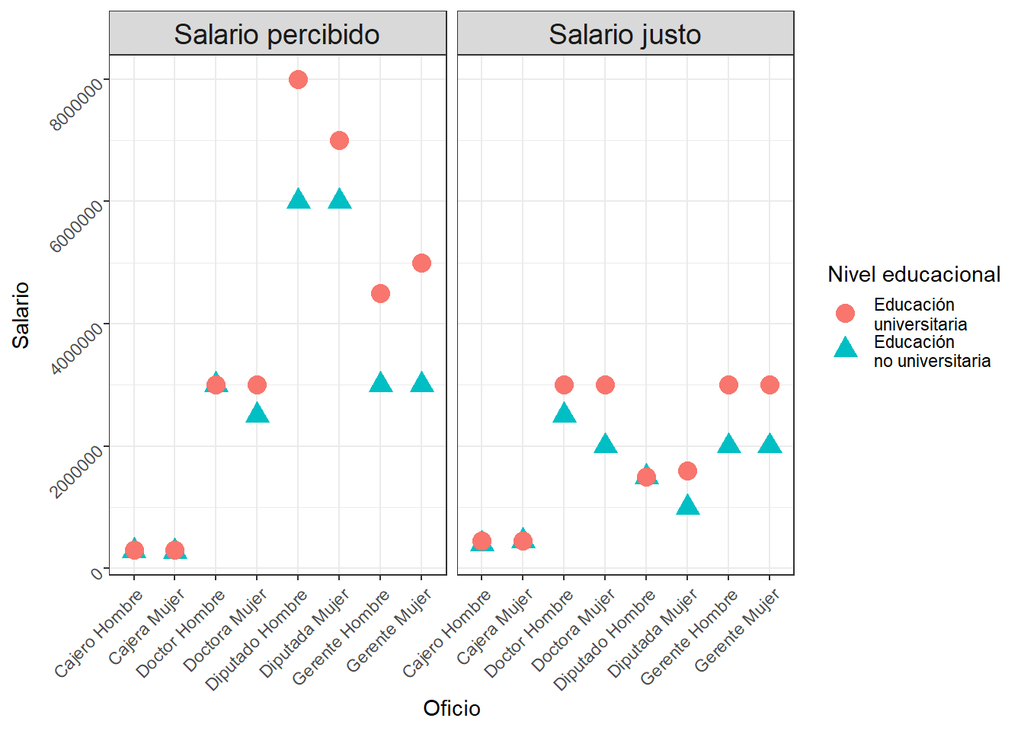

```r
base_long$educacion_rec <- factor(base_long$educacion_rec, labels = c("No universitario", "Universitario"))
base_long$educacion_rec <- factor(base_long$educacion_rec, levels = c("Universitario", "No universitario"))

plot_educ <- base_long %>% filter(!is.na(base_long$educacion_rec)) %>%
  ggplot(aes(x = oficio, y = mean, color=educacion_rec)) +
  geom_point(size=4, aes(shape=educacion_rec)) +
  labs(color = "educacion_rec", shape="educacion_rec") +
  xlab("Oficio") + ylab("Salario")  +
  theme_bw() +
  theme(axis.text = element_text(angle = 45, hjust = 1),
        strip.text.x = element_text(size = 14)) +
  facet_wrap(~tipo) +
  scale_x_discrete(label = c("Cajero Hombre", "Cajera Mujer", "Doctor Hombre", "Doctora Mujer", "Diputado Hombre", "Diputada Mujer", "Gerente Hombre", "Gerente Mujer")) +
  scale_color_discrete(labels = c("Educación
universitaria", "Educación
no universitaria"))+
  guides(color=guide_legend(title="Nivel educacional"),
         shape=guide_legend(title="Nivel educacional"))+
  scale_shape_discrete(labels = c("Educación
universitaria", "Educación
no universitaria"))

plot_educ
```

```r
ggsave(plot_educ, file = "output/graphs/des_dif_salarios_ambos_educ.png", width = 12,height = 7)
```

# 8 salario real (mediana de percepción cuánto ganan en cada oficio diferenciado por sexo, según educacion y sexo)

```r
salario_real = desiguales_pond %>% filter(!is.na(educacion_rec)) %>%
  group_by(educacion_rec, sexo) %>%
  summarise(n = n(),
            cajero_hombre = survey_median(p12_sal_real_cajero_h, na.rm = T),
            cajero_mujer = survey_median(p12_sal_real_cajero_m, na.rm = T),
            gerente_hombre = survey_median(p12_sal_real_gerente_h, na.rm = T),
            gerente_mujer = survey_median(p12_sal_real_gerente_m, na.rm = T),
            doctor_hombre = survey_median(p12_sal_real_doctor_h, na.rm = T),
            doctor_mujer = survey_median(p12_sal_real_doctor_m, na.rm = T),
            diputado_hombre = survey_median(p12_sal_real_diput_h, na.rm = T),
            diputado_mujer = survey_median(p12_sal_real_diput_m, na.rm = T)
            )
```

```r
salario_real_long <- salario_real %>%
  pivot_longer(cols = c("cajero_hombre",
                        "cajero_mujer",
                        "gerente_hombre",
                        "gerente_mujer",
                        "doctor_hombre",
                        "doctor_mujer",
                        "diputado_hombre",
                        "diputado_mujer"),
               names_to = "oficio",
               values_to = "mean")

salario_real_long$oficio <- factor(salario_real_long$oficio, levels = c("cajero_hombre", "cajero_mujer", "doctor_hombre", "doctor_mujer", "diputado_hombre", "diputado_mujer", "gerente_hombre", "gerente_mujer"))
```

# 9 salario ideal (Mediana de percepción cuánto deberían ganar en cada oficio diferenciado por sexo, según educacion y sexo)

```r
salario_ideal = desiguales_pond %>% filter(!is.na(educacion_rec)) %>%
  group_by(educacion_rec, sexo) %>%
  summarise(n = n(),
            cajero_hombre = survey_median(p12_sal_ideal_cajero_h, na.rm = T),
            cajero_mujer = survey_median(p12_sal_ideal_cajero_m, na.rm = T),
            gerente_hombre = survey_median(p12_sal_ideal_gerente_h, na.rm = T),
            gerente_mujer = survey_median(p12_sal_ideal_gerente_m, na.rm = T),
            doctor_hombre = survey_median(p12_sal_ideal_doctor_h, na.rm = T),
            doctor_mujer = survey_median(p12_sal_ideal_doctor_m, na.rm = T),
            diputado_hombre = survey_median(p12_sal_ideal_diput_h, na.rm = T),
            diputado_mujer = survey_median(p12_sal_ideal_diput_m, na.rm = T)
            )
```

```r
salario_ideal_long <- salario_ideal %>%
  pivot_longer(cols = c("cajero_hombre",
                        "cajero_mujer",
                        "gerente_hombre",
                        "gerente_mujer",
                        "doctor_hombre",
                        "doctor_mujer",
                        "diputado_hombre",
                        "diputado_mujer"),
               names_to = "oficio",
               values_to = "mean")

salario_ideal_long$oficio <- factor(salario_ideal_long$oficio, levels = c("cajero_hombre", "cajero_mujer", "doctor_hombre", "doctor_mujer", "diputado_hombre", "diputado_mujer", "gerente_hombre", "gerente_mujer"))
```

```r
salario_ideal_long <- salario_ideal_long %>% select(sexo, educacion_rec, oficio, salario_ideal = mean)
salario_real_long <- salario_real_long %>% ungroup() %>%  select(salario_real = mean)

base <- cbind(salario_ideal_long, salario_real_long)

base_long <- base %>%
  pivot_longer(cols = c("salario_ideal",
                        "salario_real"),
               names_to = "tipo",
               values_to = "mean")
base_long$tipo <- factor(base_long$tipo, levels = c("salario_real", "salario_ideal"))
base_long$tipo <- factor(base_long$tipo, labels = c("Salario percibido", "Salario justo"))
```

- salario real

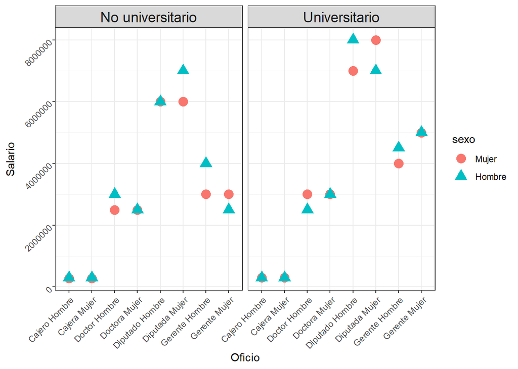

```r
base_long$educacion_rec <- factor(base_long$educacion_rec, labels = c("No universitario", "Universitario"))

plot_real_educ_sexo <- base_long %>% filter(tipo=="Salario percibido") %>%
  ggplot(aes(x = oficio, y = mean, color=sexo)) +
  geom_point(size=4, aes(shape=sexo)) +
  labs(color = "sexo", shape="sexo") +
  xlab("Oficio") + ylab("Salario")  +
  theme_bw() +
  theme(axis.text = element_text(angle = 45, hjust = 1),
        strip.text.x = element_text(size = 14)) +
  facet_wrap(~educacion_rec) +
  scale_x_discrete(label = c("Cajero Hombre", "Cajera Mujer", "Doctor Hombre", "Doctora Mujer", "Diputado Hombre", "Diputada Mujer", "Gerente Hombre", "Gerente Mujer"))

plot_real_educ_sexo
```

```r
ggsave(plot_real_educ_sexo, file = "output/graphs/des_dif_salarios_real_educ_sexo.png", width = 12,height = 7)
```

- salario ideal

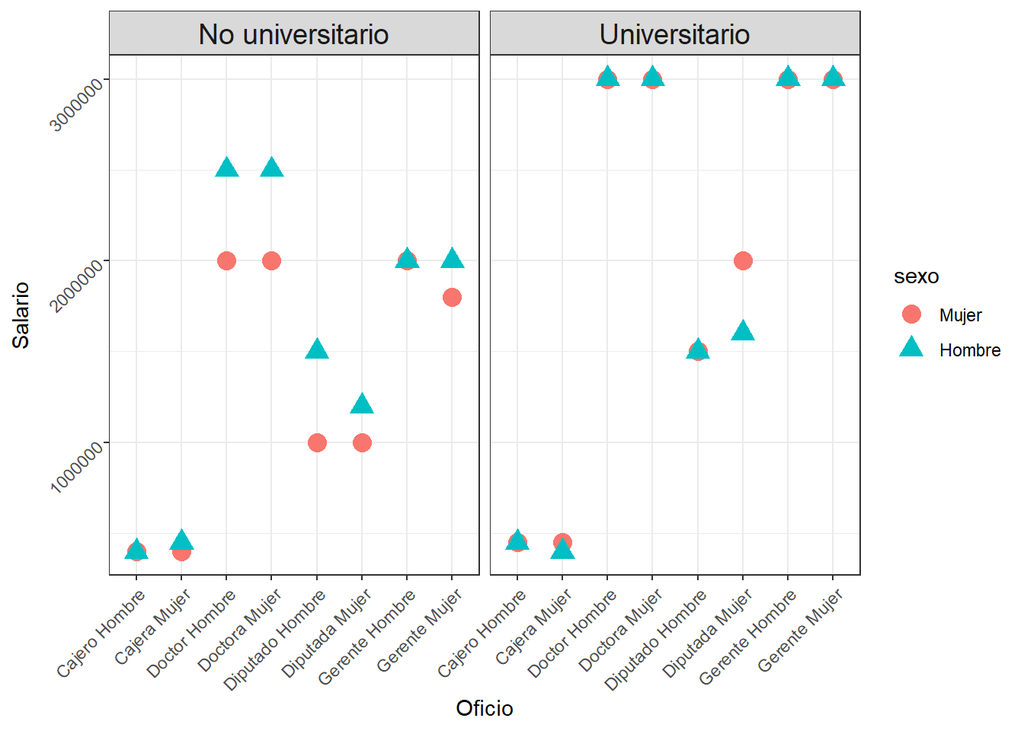

```r
plot_ideal_educ_sexo <- base_long %>% filter(tipo=="Salario justo") %>%
  ggplot(aes(x = oficio, y = mean, color=sexo)) +
  geom_point(size=4, aes(shape=sexo)) +
  labs(color = "sexo", shape="sexo") +
  xlab("Oficio") + ylab("Salario")  +
  theme_bw() +
  theme(axis.text = element_text(angle = 45, hjust = 1),
        strip.text.x = element_text(size = 14)) +
  facet_wrap(~educacion_rec) +
  scale_x_discrete(label = c("Cajero Hombre", "Cajera Mujer", "Doctor Hombre", "Doctora Mujer", "Diputado Hombre", "Diputada Mujer", "Gerente Hombre", "Gerente Mujer"))

plot_ideal_educ_sexo
```

```r
ggsave(plot_ideal_educ_sexo, file = "output/graphs/des_dif_salarios_ideal_educ_sexo.png", width = 12,height = 7)
```